# Jingyu_Gao_Junior_D_S_Part_I

JingyuGao

2/18/2018

### Introduction

This document analyses the global trend of **access to sanitation facilities** data provided by the World Development Indicators database using data from 1990 to 2015. It answers three primary questions:

- How is access to sanitation facilities changing over time?
- Is there an overall trend?
- Does it vary by [income group](https://datahelpdesk.worldbank.org/knowledgebase/articles/906519-world-bank-country-and-lending-groups)?

Access to sanitation facilities is [defined](https://data.worldbank.org/indicator/SH.STA.ACSN) as **the percentage of the population using improved sanitation facilities**. Improved sanitation facilities are likely to ensure hygienic separation of human excreta from human contact. They include flush/pour flush (to piped sewer system, septic tank, pit latrine), ventilated improved pit (VIP) latrine, pit latrine with slab, and composting toilet.

### Global Trend 1990-2015

Over the period 1990-2015, access to sanitation facilities has been improved steadily, but such improvement is heterogeneous across the world. East Asia and Pacific (EAP) witnessed the biggest success: over 74.89 percent of population are now using improved sanitation facilities, substantially increasing from 47.53 in 1990. Since 2001, people in EAP have greater access to sanitation facilities than world average. At the same time, developing countries in South Asia (SA) and Sub-Sahara Africa (SSA) still lag behind the world average, despite significant improvement in SA. Condition in SSA barely changed: 29.79 percent of population have access to better sanitation facilities in 2015, only slightly higher than 23.78 in 1990.

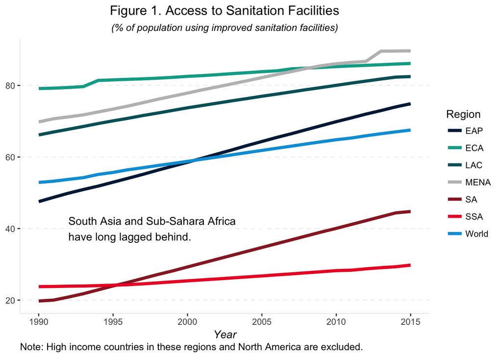

### Income and Better Sanitation

As indicated in figure 2, greater income is associated with greater access to facilities that ensure hygienic seperation of human excreta. Almost everyone (over 90 percent of population) living in high income countries have such access, while in low income countries fewer than half of their population do. A comparison between 1990 and 2015 also illustrates the fact that when countries become richer, more of their citizens would use improved sanitation facilities, as shown by the points in the figure that shifted upward and rightward in 2015 compared to 1990.

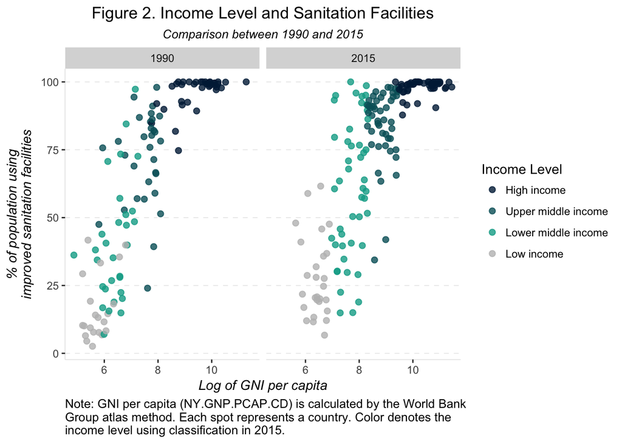